# Magolego SNA - Lab 3

## Barabasi-Albert model. Preferential attachement

### Generate Barabasi-Albert graphs

Again, we can use a function in igraph

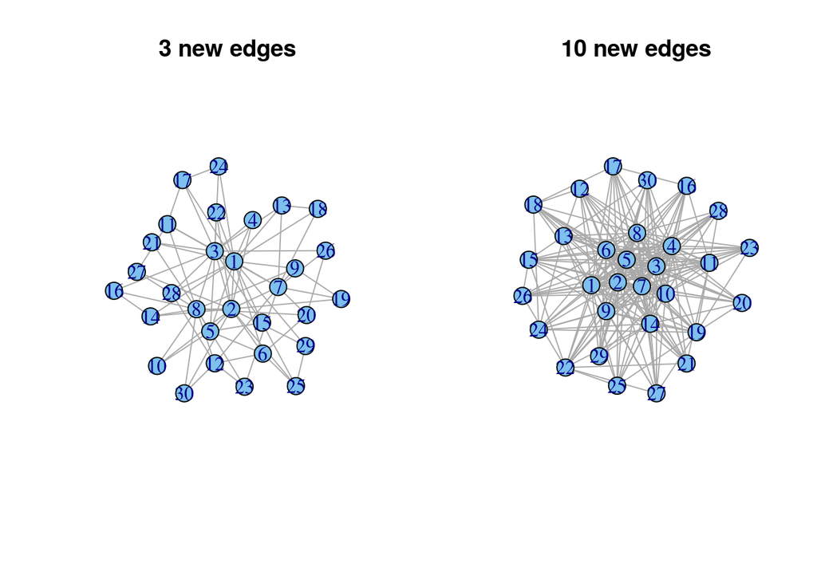

```r
b1=barabasi.game(30, power = 1, m=3, directed=F)
b2=barabasi.game(30, power = 1, m=10, directed=F)

op <- par(mfrow = c(1, 2))
plot(b1, layout=layout.fruchterman.reingold(b1), main="3 new edges")
plot(b2, layout=layout.fruchterman.reingold(b2), main="10 new edges")
```

```r
par(op)
```

### Degree distribution

Now we will look at degree distributions for the Barabasi-Albert graphs. We will plot degree distributions for our small graphs and for a larger graph:

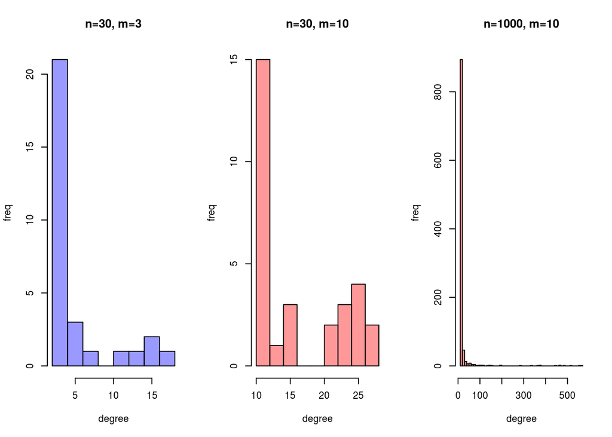

```r
b3=barabasi.game(1000, power = 1, m=10, directed=F)

db1 <- degree(b1)
db2 <- degree(b2)
db3 <- degree(b3)
op <- par(mfrow = c(1, 3))
hist(db1, breaks=10, col=rgb(0,0,1,.4), xlab="degree",ylab="freq", main="n=30, m=3")
hist(db2, breaks=10, col=rgb(1,0,0,.4),xlab="degree",ylab="freq", main="n=30, m=10")
hist(db3, breaks=50, col=rgb(1,0,0,.4),xlab="degree",ylab="freq", main="n=1000, m=10")
```

```r
par(op)
```

Can you estimate $\alpha$ for the third graph? Remember how to do it?

Hints:

`power.law.fit`

`fit$alpha`

```r
fit <- power.law.fit(degree(b3))
fit$alpha
```

```
## [1] 1.978949
```

### Dinamical change

Now, we will look at how clustering coefficient, average path length and node degrees change with time.

```r
avpathlen=c()
clustcoef=c()
deg30=c()
deg70=c()
ba=barabasi.game(20, power = 1, m=3, directed=F)
m=15
for (i in 21:300){
  ba=add.vertices(ba, 1)
  neib=sample(seq(1,vcount(ba)), m, prob = degree(ba,normalized = T))
  new_edges=c()
  for (n in neib){
    new_edges=c(new_edges, c(i, n))
  }
  ba=add.edges(ba, new_edges)
  avpathlen=c(avpathlen, average.path.length(ba))
  clustcoef=c(clustcoef, transitivity(ba, type="global"))
  if (i>30){
    deg30=c(deg30, degree(ba, 30))}
  if (i>70){
    deg70=c(deg70, degree(ba, 70))}
  }
```

Now we will plot average path length and clustering coefficient against the number of nodes in a graph:

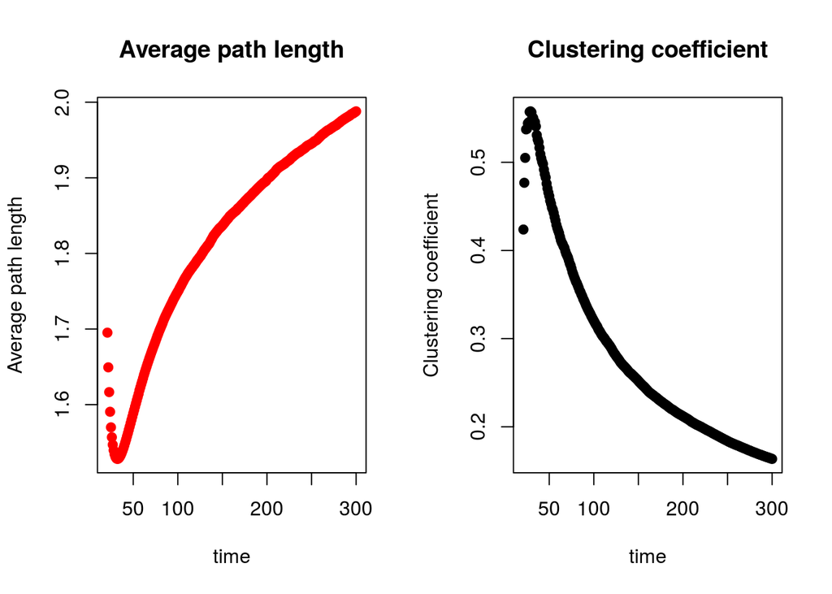

```r
xaxis=c(21:300)
op <- par(mfrow = c(1, 2))
plot(xaxis, avpathlen, pch=19, col=26, xlab="time", ylab="Average path length", main="Average path length")
plot(xaxis, clustcoef, pch=19, col=49, xlab="time", ylab="Clustering coefficient", main="Clustering coefficient")
```

```r
par(op)
```

And now we will look at node degrees:

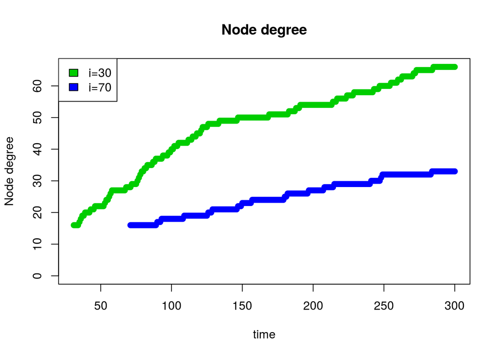

```r
plot(c(31:300), deg30, pch=19, col=35, ylim=c(0, max(deg30)), xlab="time", ylab="Node degree", main="Node degree")
points(c(71:300), deg70, pch=19, col=84)
legend("topleft", c("i=30", "i=70"), fill=c(35, 84))
```

## Small world model. Watts-Strogats model

Yet again, we will use a function in igraph:

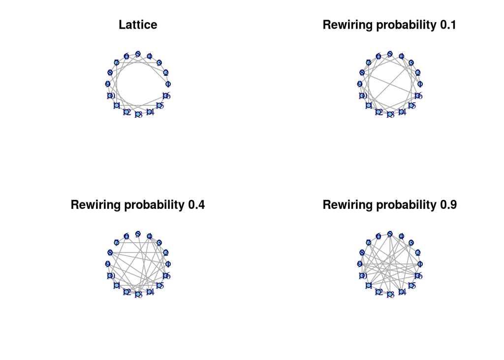

```r
lat <- graph.lattice(length=4, dim=2, nei=1)
ws1 <- watts.strogatz.game(dim=2, size=4, nei=1, p=0.1, loops = FALSE, multiple = FALSE)
ws2 <- watts.strogatz.game(dim=2, size=4, nei=1, p=0.4, loops = FALSE, multiple = FALSE)
ws3 <- watts.strogatz.game(dim=2, size=4, nei=1, p=0.9, loops = FALSE, multiple = FALSE)

op <- par(mfrow = c(2, 2))
plot(lat, layout=layout.circle(lat), main="Lattice")
plot(ws1, layout=layout.circle(ws1), main="Rewiring probability 0.1")
plot(ws2, layout=layout.circle(ws2), main="Rewiring probability 0.4")
plot(ws3, layout=layout.circle(ws3), main="Rewiring probability 0.9")
```

```r
par(op)
```

Now it’s your turn again. Can you compute clustering coefficients and average path lengths for our small world graphs?

Hints:

`transitivity(your_graph, type="global")`

`average.path.length(your_graph)`

Can you plot degree distribution for these graphs?